# The Data Science process

2022/06/30

## Learning objectives

- Understand the key elements of data science:
  - Import, tidy, explore, communicate
- Import tabular data from csv and excel files
- Understand the key elements of grammar of graphics:
- Apply the grammar of graphics to make visualizations with `ggplot2`

## Key elements of data science

**Import:** load data into `R` from CSV or Excel files

**Tidy:** real-world data is often messy and must be cleaned prior to analysis

**Understand**

- *Transform:* filter data for subsets, create new variables.
- *Visualize:* essential for understanding the data and developing insights
- *Model:* computational and statistical tools to analyze the data

**Communicate:** prepare & disseminate reports, blogs, etc.

The data science process (*R for Data Science*)

## *Import* data to `R`

- Importing data allows us to begin analysis
- Data often available in csv or excel format
- `R` has built-in functions for reading data, but these are slightly cumbersome
- Instead, we will use functions from the `readr` (for csv) and `readxl` (for excel) packages

## *Import* csv to `R`

Let’s say we want to import the following .csv file to `R`.

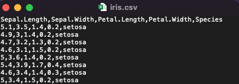

Note that the file is in a subdirectory of the working directory:

```r
list.files("Week 4 data")
```

```
## [1] "iris.csv"  "iris.xlsx"
```

## *Import* csv to `R`

We can import the .csv from using the `readr` and code below. Note that you may need to run `install.packages('readr')` if you haven’t already.

```r
library(readr)
table <- read_csv('Week 4 data/iris.csv')
print(table)
```

```
## # A tibble: 150 × 5
##    Sepal.Length Sepal.Width Petal.Length Petal.Width Species
##           <dbl>       <dbl>        <dbl>       <dbl> <chr>
##  1          5.1         3.5          1.4         0.2 setosa
##  2          4.9         3            1.4         0.2 setosa
##  3          4.7         3.2          1.3         0.2 setosa
##  4          4.6         3.1          1.5         0.2 setosa
##  5          5           3.6          1.4         0.2 setosa
##  6          5.4         3.9          1.7         0.4 setosa
##  7          4.6         3.4          1.4         0.3 setosa
##  8          5           3.4          1.5         0.2 setosa
##  9          4.4         2.9          1.4         0.2 setosa
## 10          4.9         3.1          1.5         0.1 setosa
## # … with 140 more rows
```

## *Import* excel to `R`

In excel format.

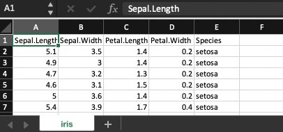

Again, the file is in a subdirectory of the working directory:

```r
list.files("Week 4 data")
```

```
## [1] "iris.csv"  "iris.xlsx"
```

## *Import* excel to `R`

We can import the .xlsx using the `readxl` package. You may need to run `install.packages('readxl')` if you haven’t already.

```r
library(readxl)

table_excel <- read_excel('Week 4 data/iris.xlsx')
print(table_excel)
```

```
## # A tibble: 150 × 5
##    Sepal.Length Sepal.Width Petal.Length Petal.Width Species
##           <dbl>       <dbl>        <dbl>       <dbl> <chr>
##  1          5.1         3.5          1.4         0.2 setosa
##  2          4.9         3            1.4         0.2 setosa
##  3          4.7         3.2          1.3         0.2 setosa
##  4          4.6         3.1          1.5         0.2 setosa
##  5          5           3.6          1.4         0.2 setosa
##  6          5.4         3.9          1.7         0.4 setosa
##  7          4.6         3.4          1.4         0.3 setosa
##  8          5           3.4          1.5         0.2 setosa
##  9          4.4         2.9          1.4         0.2 setosa
## 10          4.9         3.1          1.5         0.1 setosa
## # … with 140 more rows
```

## The `iris` dataset

The `iris` dataset (from previous slide) is common for code demonstrations. It documents properties of individual flowers from different species

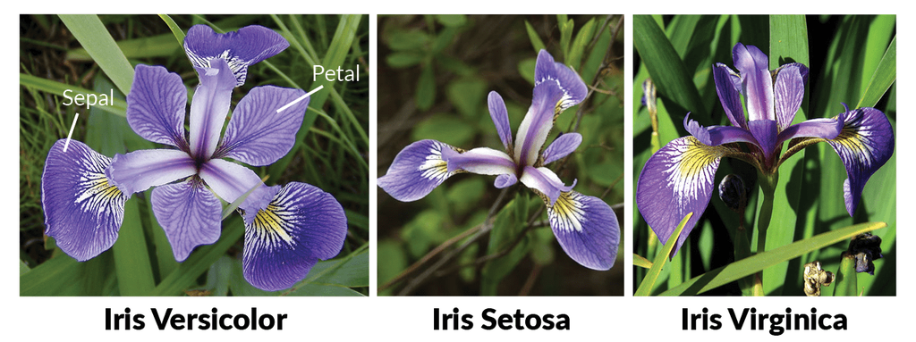

Image from: https://www.datacamp.com/tutorial/machine-learning-in-r

## Visualizing the data

Data visualization is an essential component of data science! We use visualization to:

- Understand what is in the data set
- Develop intuition for relationships in the data *before* we analyze it
- Ensure our analyses are yielding reasonable results
- Communicate important findings

1. Make sure we can import the data (*import the data*)
2. Make sure the data contain the information we expect (use `summary()` function)
3. Begin to visualize the data (either with `ggplot` or `GGally`, the latter of which we will cover later)

## The `iris` dataset

```r
summary(iris)
```

```
##   Sepal.Length    Sepal.Width     Petal.Length    Petal.Width
##  Min.   :4.300   Min.   :2.000   Min.   :1.000   Min.   :0.100
##  1st Qu.:5.100   1st Qu.:2.800   1st Qu.:1.600   1st Qu.:0.300
##  Median :5.800   Median :3.000   Median :4.350   Median :1.300
##  Mean   :5.843   Mean   :3.057   Mean   :3.758   Mean   :1.199
##  3rd Qu.:6.400   3rd Qu.:3.300   3rd Qu.:5.100   3rd Qu.:1.800
##  Max.   :7.900   Max.   :4.400   Max.   :6.900   Max.   :2.500
##        Species
##  setosa    :50
##  versicolor:50
##  virginica :50
##
##
##
```

From the `summary` output, we see that there are 4 columns of continuous variables and one column for a discrete variable. The dicrete variable has 3 categories each with 50 observations.

## Visualizing the data

Next we want to visualize the data. For now we will consider only 2 variables, `Petal.Length` vs `Petal.Width`.

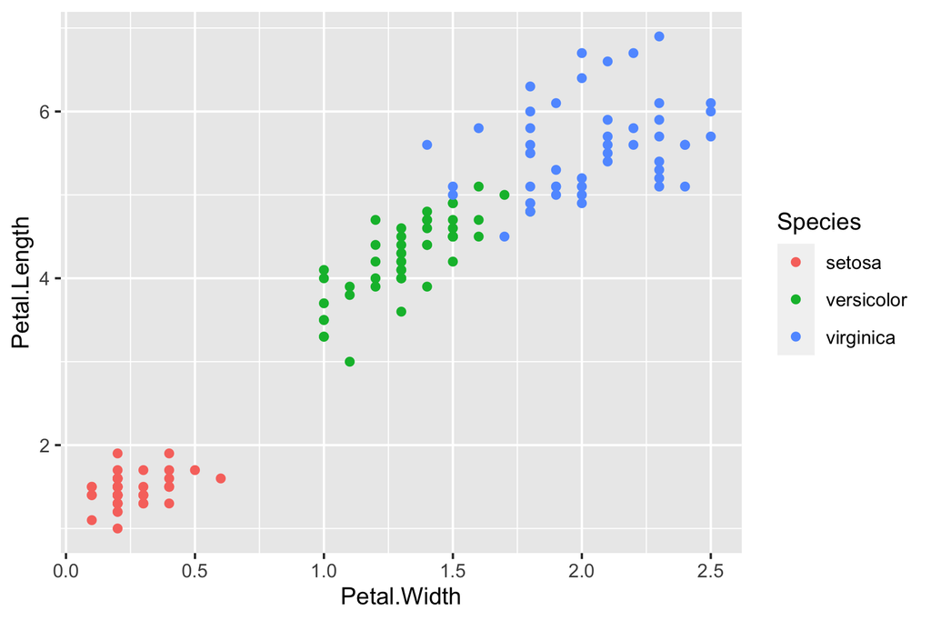

```r
library(ggplot2)
iris_plot = ggplot(data = iris) +
  geom_point(aes(x = Petal.Width, y = Petal.Length, color = Species))
iris_plot
```

–

## A grammar of graphics

- Structured way to think about data visualization:

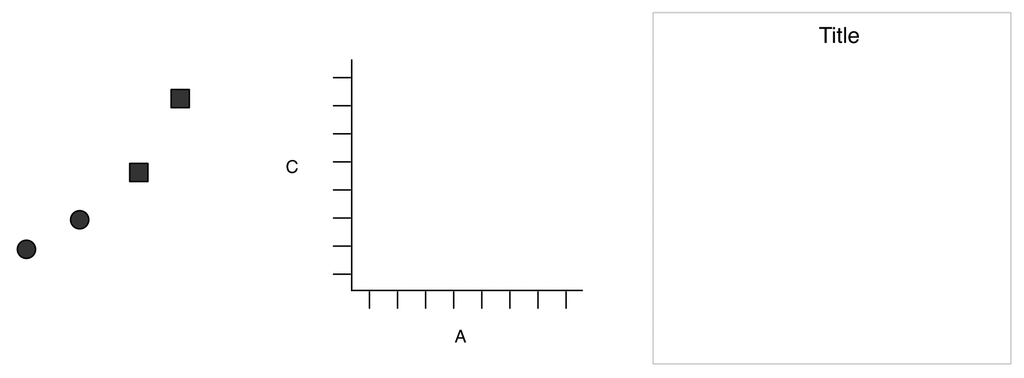

Graphics objects produced by:

- (left) **geometric objects** - e.g., points, lines, bars
- (middle) **scales and coordinate system** - scales can include shapes, colors, and other aesthetic mappings
- (right) **plot annotations**.<sup>1</sup>

- Different from most programming languages – e..g. scatterplot, barplot
- Note the shape scale present on left

## A grammar of graphics

Combining these elements produces the following figure:

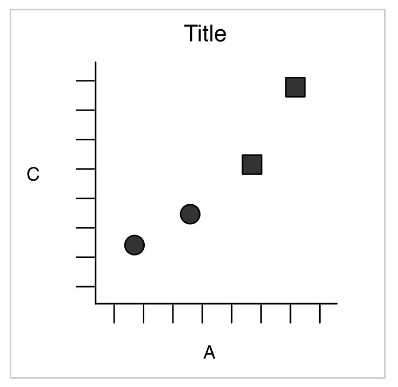

The figure is created from the following dataset. Note that the geometric objects are points. The aesthetic mapping includes `A` and `C` columns mapped to the x-y coordinate system, and the `Shape` column mapped to the shape aesthetic.

[output not shown]

[1] Wickham, 2010. A layered grammar of graphics.

## Plotting in R: `ggplot2`

In `R`, the `ggplot2` package implements the Grammar of Graphics. We can see this via the same code as before.

```r
library(ggplot2)
iris_plot = ggplot(data = iris) + #<<
  geom_point(aes(x = Petal.Width, y = Petal.Length, color = Species))
```

We initialize the `ggplot` object with a default dataset, in this case `iris` (see highlighted code). Note that the line ends with a `+` which means that `R` will interpret the next line of text as a continuation of this line of code.

## Plotting in R: `ggplot2`

In `R`, the `ggplot2` package implements the Grammar of Graphics. We can see this via the same code as before.

```r
library(ggplot2)
iris_plot = ggplot(data = iris) +
  geom_point(aes(x = Petal.Width, y = Petal.Length, color = Species)) #<<
```

The next line builds the geometric objects, coordinate system, and aesthetics.

- `geom_point()` means that our geometric objects will be points
- The `aes()` function defines aesthetic mapping of columns to various scales (including the coordinate system):
  - `x = Petal.Width` indicates the column that will map to the x-axis
  - `y = Petal.Length` indicates the column that will map to the y-axis
  - `color = Species` indicates the column that will map to color scale

## Geometric objects in ggplot

(not exhaustive)

geom_point geom_line geom_bar geom_text geom_path geom_polygon geom_segment geom_ribbon

Note that each geometric type has the requirement that aesthetics map to the coordinate system. Usually this includes x-y aesthetics, but may also include, for example, `label` (`geom_text`), `ymin` and `ymax` (`geom_ribbon`), etc.

## Aesthetic scales in ggplot

All aesthetics include a mapping (e.g. column `A` to shape) and a scale (which shapes correspond to which values).

The mapping is specified in the `aes()` function, either as a defult for the figure or within the specific geometric layer.

The scale can be taken as the default for the aesthetic and data type, or specified in a separate function.

x - `scale_x_continuous`, `scale_x_discrete`, `scale_x_manual` y - `scale_y_continuous`, `scale_y_discrete`, `scale_y_manual` color - `scale_color_continuous`, `scale_color_discrete`, `scale_color_manual` fill - `scale_fill_continuous`, `scale_fill_discrete`, `scale_fill_manual` size - `scale_size_continuous`, `scale_size_discrete`, `scale_size_manual` shape - `scale_shape_discrete`, `scale_shape_manual` linetype label (text) alpha (transparency)

## Syntax of `ggplot2`

Note that because `ggplot2` builds plots in a layered fashion, we can use a variety of syntax styles.

Here, we put the dataset inside the `geom_point()` object:

```r
ggplot() +
  geom_point(
    data = iris, #<<
    aes(x = Petal.Width, y = Petal.Length, color = Species))
```

Alternatively, we can put the `aes()` object inside the `ggplot()` function to set default aesthetics:

```r
ggplot(data = iris,
       aes(x = Petal.Width, y = Petal.Length, color = Species)) + #<<
  geom_point()
```

Each of these generates the same plot!

## Napoleon’s march on Russia

Famous depiction of the march by Charles Joseph Minard.

[figure not shown]

Begin with 422k, end with 1k Cold temperatures - depictions & stories of men freezing on side of road Elegant and minimal

## Napoleon’s march on Russia

We can reproduce a version of Minard’s map using `ggplot`. First we need the data, which is available online.

```r
cities_url = "https://raw.githubusercontent.com/stdlib-js/datasets-minard-napoleons-march/main/data/cities.csv"
cities = read_csv(cities_url)
armies_url = "https://raw.githubusercontent.com/stdlib-js/datasets-minard-napoleons-march/main/data/army.csv"
armies = read_csv(armies_url)
```

```r
armies
```

```
## # A tibble: 48 × 5
##      lon   lat   size direction division
##    <dbl> <dbl>  <dbl> <chr>        <dbl>
##  1  24    54.9 340000 A                1
##  2  24.5  55   340000 A                1
##  3  25.5  54.5 340000 A                1
##  4  26    54.7 320000 A                1
##  5  27    54.8 300000 A                1
##  6  28    54.9 280000 A                1
##  7  28.5  55   240000 A                1
##  8  29    55.1 210000 A                1
##  9  30    55.2 180000 A                1
## 10  30.3  55.3 175000 A                1
## # … with 38 more rows
```

```r
cities[1:10,]
```

```
## # A tibble: 10 × 3
##      lon   lat city
##    <dbl> <dbl> <chr>
##  1  24    55   Kowno
##  2  25.3  54.7 Wilna
##  3  26.4  54.4 Smorgoni
##  4  26.8  54.3 Molodexno
##  5  27.7  55.2 Gloubokoe
##  6  27.6  53.9 Minsk
##  7  28.5  54.3 Studienska
##  8  28.7  55.5 Polotzk
##  9  29.2  54.4 Bobr
## 10  30.2  55.3 Witebsk
```

## Napoleon’s march on Russia

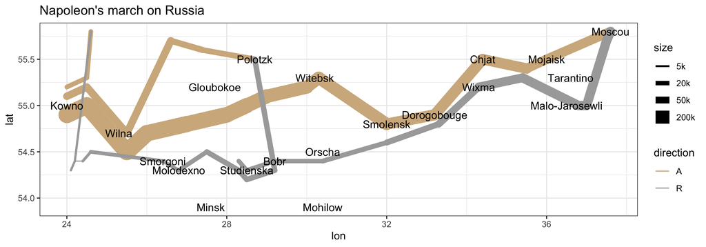

```r
ggplot(armies) +
  geom_path(aes(lon, lat, size = size, color = direction,
                group = division), lineend = 'round') +
  geom_text(data = cities, aes(x = lon, y = lat, label = city)) +
  scale_size_continuous(breaks = c(5e3, 2e4, 5e4, 2e5),
                        labels = c("5k", "20k", "50k", "200k"),
                        range = c(0.5, 8)) +
  scale_color_manual(values = c("tan", 'darkgray')) +
  ggtitle("Napoleon's march on Russia") + theme_bw()
```

## Specifiying the legend scale for size

`scale_size_continuous` includes the following key arguments:

- `breaks` indicate which sizes should be shown
- `labels` provide the text for each of the `breaks`
- `range` controls the actual size of the linewidth

## Outline of remaining slides

- Additional timeseries dataset
- long format data
- `scale_size_*`
- `scale_color_*`, `scale_fill_*`
- `scale_linetype_*`
- `scale_x_*`, `scale_y_*`
- `scale_shape_*`
- `geom_bar`
- `geom_line`
- `geom_text`
- `facet_wrap`
- `theme`
- In-class activity - plotting data